# Supporting Information: ‘Sex differences in allometry for phenotypic traits indicate that females are not scaled males’

Laura A. B. Wilson, Susanne R. K. Zajitschek, Malgorzata Lagisz, Jeremy Mason, Hamed Haselimashhadi & Shinichi Nakagawa

The document mainly provide the description of the main dataset, and the R scripts and their outputs for the paper “Sex differences in allometry for phenotypic traits indicate that females are not scaled males”.

# Setting-up

## Loading packages

```r
# older version of the orchaRd package
#devtools::install_github("itchyshin/orchard_plot", subdir = "orchaRd", force = TRUE, build_vignettes = TRUE)

pacman::p_load(tidyverse,
               purrr,
               metafor,
               poolr,
               patchwork,
               orchaRd, # older version:
               broom.mixed,
               here,
               nlme,
               pander,
               brms,
               kableExtra,
               formatR,
               knitr,
               brms,
               rstan
               )
```

## Loading custum functions

We load custom function not included in the packages above.

- functions for centering each group to its mean (group-wise centering): `groupScale`
- functions for calculating ‘parameters’ (intercepts, slopes and residuals SDs for both males and females) : `get_parmetersN`
- functions for drawing orchard plots (modified from the original): `orchard_plot2` and assoicated functions.

```r
# custom function for within-group cenering (or z transformation)
groupScale <- function(formula, data = NULL, center = TRUE, scale = FALSE) {
    if (is.null(data))
        data <- model.frame(formula)
    scaled <- rep(NA, nrow(data))  #empty vector
    for (i in unique(data[, 2])) {
        elements <- which(data[, 2] == i)
        scaled[elements] <- scale(data[elements, 1], scale = scale, center = center)
    }
    return(scaled)
}



# function to get what we need from these 2 models (you can include models in
# this function as well)
get_parmetersN <- function(i) {

    # centering weights separately for each

    ln_c_weight <- groupScale(log(i[["weight"]]) ~ i[["sex"]])
    i[, "ln_c_weight"] <- ln_c_weight
    model_f <- lme((scale(log(data_point))) ~ sex * ln_c_weight, random = list(metadata_group = ~ln_c_weight,
        date_of_experiment = ~1), weights = varIdent(form = ~1 | sex), control = lmeControl(opt = "optim"),
        data = i)

    model_m <- lme((scale(log(data_point))) ~ relevel(sex, ref = "male") * ln_c_weight,
        random = list(metadata_group = ~ln_c_weight, date_of_experiment = ~1), weights = varIdent(form = ~1 |
            sex), control = lmeControl(opt = "optim"), data = i)
    # getting all we want
    females <- broom.mixed::tidy(model_f)
    males <- broom.mixed::tidy(model_m)
    # gets variance weights
    weights <- attr(model_f$modelStruct$varStruct, "weights")
    male_correction <- 1/weights[which(names(weights) == "male")[1]]
    female_correction <- 1/weights[which(names(weights) == "female")[1]]

    # get parameters
    parameter_name <- tolower(i[["parameter_name"]][1])
    m_n <- sum(i[["sex"]] == "male")  # sample size for males
    f_n <- sum(i[["sex"]] == "female")  # N fo females
    f_intercept <- as.numeric(females[1, 4])
    f_intercept_se <- as.numeric(females[1, 5])
    f_slope <- as.numeric(females[3, 4])
    f_slope_se <- as.numeric(females[3, 5])
    m_intercept <- as.numeric(males[1, 4])
    m_intercept_se <- as.numeric(males[1, 5])
    m_slope <- as.numeric(males[3, 4])
    m_slope_se <- as.numeric(males[3, 5])
    fm_diff_int <- as.numeric(males[2, 4])
    fm_diff_int_se <- as.numeric(males[2, 5])
    fm_diff_int_p <- as.numeric(males[2, 8])
    fm_diff_slope <- as.numeric(males[4, 4])
    fm_diff_slope_se <- as.numeric(males[4, 5])
    fm_diff_slope_p <- as.numeric(males[4, 8])
    group_sd <- as.numeric(VarCorr(model_f)[, 2][2])
    g_slope_sd <- as.numeric(VarCorr(model_f)[, 2][3])
    batch_sd <- as.numeric(VarCorr(model_f)[, 2][5])
    f_sd <- as.numeric(VarCorr(model_f)[, 2][6]) * female_correction
    m_sd <- as.numeric(VarCorr(model_f)[, 2][6]) * male_correction

    # putting it together
    paras <- c(parameter_name, f_n, m_n, f_intercept, f_intercept_se, f_slope, f_slope_se,
        m_intercept, m_intercept_se, m_slope, m_slope_se, fm_diff_int, fm_diff_int_se,
        fm_diff_int_p, fm_diff_slope, fm_diff_slope_se, fm_diff_slope_p, group_sd,
        g_slope_sd, batch_sd, f_sd, m_sd)
    names(paras) <- c("parameter_name", "f_n", "m_n", "f_intercept", "f_intercept_se",
        "f_slope", "f_slope_se", "m_intercept", "m_intercept_se", "m_slope", "m_slope_se",
        "fm_diff_int", "fm_diff_int_se", "fm_diff_int_p", "fm_diff_slope", "fm_diff_slope_se",
        "fm_diff_slope_p", "group_sd", "g_slope_sd", "batch_sd", "f_sd", "m_sd")
    invisible(paras)

}


# creating orchard plots

orchard_plot2 <- function(object, mod = "Int", xlab, N = "none", alpha = 0.5, angle = 90,
    cb = FALSE, k = TRUE, transfm = c("none", "tanh"), point.size = 3, condition.lab = "Condition") {
    transfm <- match.arg(transfm)
    if (any(class(object) %in% c("rma.mv", "rma"))) {
        if (mod != "Int") {
            object <- mod_results(object, mod)
        } else {
            object <- mod_results(object, mod = "Int")
        }
    }
    mod_table <- object$mod_table
    data <- object$data
    data$moderator <- factor(data$moderator, levels = mod_table$name, labels = mod_table$name)
    data$scale <- (1/sqrt(data[, "vi"]))
    legend <- "Precision (1/SE)"
    if (any(N != "none")) {
        data$scale <- N
        legend <- "Sample Size (N)"
    }
    if (transfm == "tanh") {
        cols <- sapply(mod_table, is.numeric)
        mod_table[, cols] <- Zr_to_r(mod_table[, cols])
        data$yi <- Zr_to_r(data$yi)
        label <- xlab
    } else {
        label <- xlab
    }
    mod_table$K <- as.vector(by(data, data[, "moderator"], function(x) length(x[,
        "yi"])))
    group_no <- length(unique(mod_table[, "name"]))
    cbpl <- c("#E69F00", "#009E73", "#F0E442", "#0072B2", "#D55E00", "#CC79A7", "#56B4E9",
        "#999999")
    if (names(mod_table)[2] == "condition") {
        condition_no <- length(unique(mod_table[, "condition"]))
        plot <- ggplot2::ggplot() + ggbeeswarm::geom_quasirandom(data = data, ggplot2::aes(y = yi,
            x = moderator, size = scale, colour = moderator), alpha = alpha) + ggplot2::geom_hline(yintercept = 0,
            linetype = 2, colour = "black", alpha = alpha) + ggplot2::geom_linerange(data = mod_table,
            ggplot2::aes(x = name, ymin = lowerCL, ymax = upperCL), size = 1.2, position = ggplot2::position_dodge2(width = 0.3)) +
            ggplot2::geom_pointrange(data = mod_table, ggplot2::aes(y = estimate,
                x = name, ymin = lowerPR, ymax = upperPR, shape = as.factor(condition),
                fill = name), size = 0.5, position = ggplot2::position_dodge2(width = 0.3)) +
            ggplot2::scale_shape_manual(values = 20 + (1:condition_no)) + ggplot2::coord_flip() +
            ggplot2::theme_bw() + ggplot2::guides(fill = "none", colour = "none") +
            ggplot2::theme(legend.position = c(0, 1), legend.justification = c(0,
                1)) + ggplot2::theme(legend.title = ggplot2::element_text(size = 9)) +
            ggplot2::theme(legend.direction = "horizontal") + ggplot2::theme(legend.background = ggplot2::element_blank()) +
            ggplot2::labs(y = label, x = "", size = legend) + ggplot2::labs(shape = condition.lab) +
            ggplot2::theme(axis.text.y = ggplot2::element_text(size = 10, colour = "black",
                hjust = 0.5, angle = angle))
        plot <- plot + ggplot2::annotate("text", y = (max(data$yi) + (max(data$yi) *
            0.1)), x = (seq(1, group_no, 1) + 0.3), label = paste("italic(k)==",
            mod_table$K[1:group_no]), parse = TRUE, hjust = "right", size = 3.5)
    } else {
        plot <- ggplot2::ggplot(data = mod_table, ggplot2::aes(x = estimate, y = name)) +
            ggbeeswarm::geom_quasirandom(data = data, ggplot2::aes(x = yi, y = moderator,
                size = scale, colour = moderator), groupOnX = FALSE, alpha = alpha) +
            ggplot2::geom_errorbarh(ggplot2::aes(xmin = lowerPR, xmax = upperPR),
                height = 0, show.legend = FALSE, size = 0.5, alpha = 0.6) + ggplot2::geom_errorbarh(ggplot2::aes(xmin = lowerCL,
            xmax = upperCL), height = 0, show.legend = FALSE, size = 1.2) + ggplot2::geom_vline(xintercept = 0,
            linetype = 2, colour = "black", alpha = alpha) + ggplot2::geom_point(ggplot2::aes(fill = name),
            size = point.size, shape = 21) + ggplot2::theme_bw() + ggplot2::guides(fill = "none",
            colour = "none") + ggplot2::theme(legend.position = c(1, 0), legend.justification = c(1,
            0)) + ggplot2::theme(legend.title = ggplot2::element_text(size = 9)) +
            ggplot2::theme(legend.direction = "horizontal") + ggplot2::theme(legend.background = ggplot2::element_blank()) +
            ggplot2::labs(x = label, y = "", size = legend) + ggplot2::theme(axis.text.y = ggplot2::element_text(size = 10,
            colour = "black", hjust = 0.5, angle = angle))
        if (k == TRUE) {
            plot <- plot + ggplot2::annotate("text", x = (max(data$yi) + (max(data$yi) *
                0.1)), y = (seq(1, group_no, 1) + 0.3), label = paste("italic(k)==",
                mod_table$K), parse = TRUE, hjust = "right", size = 3.5)
        }
    }
    if (cb == TRUE) {
        plot <- plot + ggplot2::scale_fill_manual(values = cbpl) + ggplot2::scale_colour_manual(values = cbpl)
    }
    return(plot)
}
```

```r
# mod_result old

#' @title get_est
#' @description Function gets estimates from rma objects (metafor)
#' @param model rma.mv object
#' @param mod the name of a moderator. If meta-analysis (i.e. no moderator, se mod = 'Int')
#' @author Shinichi Nakagawa - s.nakagawa@unsw.edu.au
#' @author Daniel Noble - daniel.noble@anu.edu.au
#' @export

get_est <- function(model, mod) {
    name <- firstup(as.character(stringr::str_replace(row.names(model$beta), {
        {
            mod
        }
    }, "")))

    estimate <- as.numeric(model$beta)
    lowerCL <- model$ci.lb
    upperCL <- model$ci.ub

    table <- tibble::tibble(name = factor(name, levels = name, labels = name), estimate = estimate,
        lowerCL = lowerCL, upperCL = upperCL)

    return(table)
}


#' @title get_pred
#' @description Function to get prediction intervals (crediblity intervals) from rma objects (metafor)
#' @param model rma.mv object
#' @param mod the name of a moderator
#' @author Shinichi Nakagawa - s.nakagawa@unsw.edu.au
#' @author Daniel Noble - daniel.noble@anu.edu.au
#' @export

get_pred <- function(model, mod) {

    name <- firstup(as.character(stringr::str_replace(row.names(model$beta), {
        {
            mod
        }
    }, "")))
    len <- length(name)

    if (len != 1) {
        newdata <- matrix(NA, ncol = len, nrow = len)

        pred <- metafor::predict.rma(model, newmods = diag(len), tau2.levels = 1:len,
            gamma2.levels = 1:len)
    } else {
        pred <- metafor::predict.rma(model)
    }
    lowerPR <- pred$cr.lb
    upperPR <- pred$cr.ub

    table <- tibble::tibble(name = factor(name, levels = name, labels = name), lowerPR = lowerPR,
        upperPR = upperPR)
    return(table)
}

#' @title firstup
#' @description Uppercase moderator names
#' @param x a character string
#' @author Shinichi Nakagawa - s.nakagawa@unsw.edu.au
#' @author Daniel Noble - daniel.noble@anu.edu.au
#' @return Returns a character string with all combinations of the moderator level names with upper case first letters
#' @export
firstup <- function(x) {
    substr(x, 1, 1) <- toupper(substr(x, 1, 1))
    x
}

#' @title get_data
#' @description Collects and builds the data used to fit the rma.mv or rma model in metafor
#' @param model rma.mv object
#' @param mod the moderator variable
#' @author Shinichi Nakagawa - s.nakagawa@unsw.edu.au
#' @author Daniel Noble - daniel.noble@anu.edu.au
#' @return Returns a data frame
#' @export
#'
get_data <- function(model, mod) {
    X <- as.data.frame(model$X)
    names <- vapply(stringr::str_split(colnames(X), {
        {
            mod
        }
    }), function(x) paste(unique(x), collapse = ""), character(1L))

    moderator <- matrix(ncol = 1, nrow = dim(X)[1])

    for (i in 1:ncol(X)) {
        moderator <- ifelse(X[, i] == 1, names[i], moderator)
    }
    moderator <- firstup(moderator)
    yi <- model$yi
    vi <- model$vi
    type <- attr(model$yi, "measure")

    data <- data.frame(yi, vi, moderator, type)
    return(data)

}

#' @title mod_results
#' @description Using a metafor model object of class rma or rma.mv it creates a table of model results containing the mean effect size estimates for all levels of a given categorical moderator, their corresponding confidence intervals and prediction intervals
#' @param model rma.mv object
#' @param mod the name of a moderator; put 'Int' if the intercept model (meta-analysis) or no moderators.
#' @return A data frame containing all the model results including mean effect size estimate, confidence and prediction intervals
#' @author Shinichi Nakagawa - s.nakagawa@unsw.edu.au
#' @author Daniel Noble - daniel.noble@anu.edu.au
#' @examples
#' \dontrun{data(eklof)
#' eklof<-metafor::escalc(measure='ROM', n1i=N_control, sd1i=SD_control,
#' m1i=mean_control, n2i=N_treatment, sd2i=SD_treatment, m2i=mean_treatment,
#' data=eklof)
#' # Add the unit level predictor
#' eklof$Datapoint<-as.factor(seq(1, dim(eklof)[1], 1))
#' # fit a MLMR - accouting for some non-independence
#' eklof_MR<-metafor::rma.mv(yi=yi, V=vi, mods=~ Grazer.type-1, random=list(~1|ExptID,
#' ~1|Datapoint), data=eklof)
#' results <- mod_results(eklof_MR, mod = 'Grazer.type')
#' }
#' @export

mod_results <- function(model, mod) {

    if (all(class(model) %in% c("rma.mv", "rma.uni", "rma")) == FALSE) {
        stop("Sorry, you need to fit a metafor model of class rma.mv or rma")
    }

    data <- get_data(model, mod)

    # Get confidence intervals
    CI <- get_est(model, mod)

    # Get prediction intervals
    PI <- get_pred(model, mod)

    model_results <- list(mod_table = cbind(CI, PI[, -1]), data = data)

    class(model_results) <- "orchard"

    return(model_results)

}

#' @title print.orchard
#' @description Print method for class 'orchard'
#' @param object x an R object of class orchard
#' @param ... Other arguments passed to print
#' @author Shinichi Nakagawa - s.nakagawa@unsw.edu.au
#' @author Daniel Noble - daniel.noble@anu.edu.au
#' @return Returns a data frame
#' @export
#'
print.orchard <- function(object, ...) {
    return(object$mod_table)
}
```

## Loading raw data and group category

```r
# loading data
dat_list <- readRDS(here("data/dat_list.rds"))

# grouping for category and parameter_group (this is from Zajitschek et al.
# 2020 eLife; slightly modfied)
dat_category <- read_csv(here("data/cateogry_parameter2.csv"))
```

# Data preparation

## Obtaining intersepcts, slopes and residual SDs

```r
# run function across list of matrices
Fin_dat <- map_dfr(dat_list, get_parmetersN)

# Fin_dat[Fin_dat$parameter_name == 'light side time spent',]

# remove 'body weight' duplicates
dat <- Fin_dat[-c(27:30), ]

dat %>%
    left_join(dat_category, by = ("parameter_name" = "parameter_name")) %>%
    arrange(Category) -> dat

write_csv(dat, here("data/data_parameters3.csv"))

# first getting p values - the contrasts between males and females for

dat <- read_csv(here("data/data_parameters3.csv"))

# assess number of traits with sig shifts in intercept and slope

# getting lnVR to compare SDs and SD

dat %>%
    mutate(lnVR = log(f_sd/m_sd) + 1/(2 * (f_n - 3)) - 1/(2 * (m_n - 3)), VlnVR = 1/(2 *
        (f_n - 3)) + 1/(2 * (m_n - 3)), low_lnVR = lnVR - qnorm(0.975) * VlnVR, high_lnVR = lnVR +
        qnorm(0.975) * VlnVR, t_val_sd = lnVR/sqrt(VlnVR), p_val_sd = 2 * (1 - pt(abs(t_val_sd),
        f_n - 1 + m_n - 1))) -> dat

write_csv(dat, here("data/data_parameters4.csv"))
```

## Dataset and meta-data

```r
# loading data
dat <- read_csv(here("data/data_parameters4.csv"))
# creating observation level random effect
dat$obs <- 1:dim(dat)[1]
# making character strings into factors
dat <- dat %>%
    mutate_if(is.character, as.factor)
# visualizing
kable(dat, "html") %>%
    kable_styling("striped", position = "left") %>%
    scroll_box(width = "100%", height = "250px")
```

| parameter_name | f_n | m_n | f_intercept | f_intercept_se | f_slope | f_slope_se | m_intercept | m_intercept_se | m_slope | m_slope_se | fm_diff_int | fm_diff_int_se | fm_diff_int_p | fm_diff_slope | fm_diff_slope_se | fm_diff_slope_p | group_sd | g_slope_sd | batch_sd | f_sd | m_sd | Category | parameter_group | lnVR | VlnVR | low_lnVR | high_lnVR | t_val_sd | p_val_sd | … |
| --- | --- | --- | --- | --- | --- | --- | --- | --- | --- | --- | --- | --- | --- | --- | --- | --- | --- | --- | --- | --- | --- | --- | --- | --- | --- | --- | --- | --- | --- | --- |
| % pre-pulse inhibition - global | 8561 | 8541 | 0.0564239 | 0.0994492 | -0.2423729 | 0.1450620 | 0.0748456 | 0.0994186 | -0.2440378 | 0.1353318 | -0.0184217 | 0.0133651 | 0.1681198 | 0.0016649 | 0.1331335 | 0.9900225 | 0.4652304 | 0.3458811 | 0.1953208 | 0.8505880 | 0.8210538 | Behaviour | pre-pulse inhibition | 0.0353391 | 0.0001170 | 0.0351098 | 0.0355684 | 3.2672853 | 0.0010880 | … |
| % pre-pulse inhibition - ppi1 | 6562 | 6503 | -0.0588790 | 0.0980896 | -0.1613827 | 0.1223095 | -0.0494744 | 0.0980716 | -0.2583376 | 0.1091075 | -0.0094046 | 0.0148132 | 0.5255213 | 0.0969549 | 0.1486181 | 0.5141728 | 0.4586464 | 0.0137749 | 0.1483939 | 0.8287429 | 0.8273713 | Behaviour | pre-pulse inhibition | 0.0016558 | 0.0001532 | 0.0013556 | 0.0019559 | 0.1337937 | 0.8935678 | … |
| % pre-pulse inhibition - ppi2 | 8483 | 8492 | -0.0221996 | 0.0778861 | -0.1090471 | 0.1376356 | -0.0337073 | 0.0779134 | -0.1463980 | 0.1292082 | 0.0115077 | 0.0143990 | 0.4241867 | 0.0373509 | 0.1436952 | 0.7949205 | 0.3560219 | 0.2572414 | 0.2075793 | 0.8912148 | 0.9082621 | Behaviour | pre-pulse inhibition | -0.0189475 | 0.0001179 | -0.0191785 | -0.0187165 | -1.7452768 | 0.0809548 | … |
| % pre-pulse inhibition - ppi3 | 8690 | 8688 | 0.0322093 | 0.0934961 | -0.2171716 | 0.1610824 | 0.0632190 | 0.0934634 | -0.2608453 | 0.1522640 | -0.0310097 | 0.0138664 | 0.0253461 | 0.0436737 | 0.1376566 | 0.7510464 | 0.4348650 | 0.4312010 | 0.2008149 | 0.8870817 | 0.8612478 | Behaviour | pre-pulse inhibition | 0.0295549 | 0.0001151 | 0.0293292 | 0.0297805 | 2.7544742 | 0.0058848 | … |
| % pre-pulse inhibition - ppi4 | 4268 | 4328 | 0.0612944 | 0.1179407 | -0.1912640 | 0.1741647 | 0.1175996 | 0.1180312 | -0.1939543 | 0.1674022 | -0.0563052 | 0.0188645 | 0.0028476 | 0.0026902 | 0.1942583 | 0.9889511 | 0.4619124 | 0.2482975 | 0.2048268 | 0.7993021 | 0.8544332 | Behaviour | pre-pulse inhibition | -0.0666977 | 0.0002328 | -0.0671541 | -0.0662414 | -4.3710128 | 0.0000125 | … |
| average duration | 664 | 643 | -0.0816591 | 0.2255075 | -0.5566012 | 0.5180983 | -0.2915073 | 0.2266183 | -0.4198573 | 0.5107688 | 0.2098482 | 0.0513940 | 0.0000474 | -0.1367440 | 0.5612930 | 0.8075642 | 0.2970454 | 0.3498296 | 0.3530233 | 0.8690468 | 0.9740378 | Behaviour | average duration | -0.1140780 | 0.0015377 | -0.1170918 | -0.1110642 | -2.9091679 | 0.0036853 | … |
| center average speed | 8808 | 8816 | 0.2524901 | 0.2449076 | 0.0403448 | 0.1105761 | 0.1520878 | 0.2449095 | 0.1165913 | 0.1098692 | 0.1004024 | 0.0049140 | 0.0000000 | -0.0762465 | 0.0455690 | 0.0943066 | 0.9160102 | 0.3560665 | 0.0938889 | 0.2995979 | 0.3057942 | Behaviour | center average speed | -0.0204712 | 0.0001135 | -0.0206937 | -0.0202487 | -1.9213477 | 0.0547040 | … |
| center distance travelled | 9152 | 9155 | 0.1274666 | 0.2566500 | -0.1208580 | 0.1337573 | 0.0631432 | 0.2566430 | -0.0476938 | 0.1301999 | 0.0643234 | 0.0082353 | 0.0000000 | -0.0731643 | 0.0767436 | 0.3404221 | 0.9591311 | 0.3716620 | 0.2152565 | 0.5263522 | 0.4861385 | Behaviour | center distance travelled | 0.0794771 | 0.0001093 | 0.0792629 | 0.0796913 | 7.6026422 | 0.0000000 | … |
| center permanence time | 9505 | 9491 | -0.1114302 | 0.1886309 | -0.1550794 | 0.1604093 | -0.0756109 | 0.1885954 | -0.2142770 | 0.1513820 | -0.0358193 | 0.0124725 | 0.0040857 | 0.0591975 | 0.1153052 | 0.6076793 | 0.7012538 | 0.3984194 | 0.4311629 | 0.8071440 | 0.7143812 | Behaviour | center time | 0.1220854 | 0.0001053 | 0.1218789 | 0.1222918 | 11.8962736 | 0.0000000 | … |
| center resting time | 6467 | 6509 | 0.0239060 | 0.2423346 | -0.1593923 | 0.1674568 | 0.0413212 | 0.2423034 | -0.2836779 | 0.1578292 | -0.0174152 | 0.0138617 | 0.2090135 | 0.1242856 | 0.1478565 | 0.4005994 | 0.7638406 | 0.3289385 | 0.3174212 | 0.7236930 | 0.6663582 | Behaviour | center time | 0.0825404 | 0.0001542 | 0.0822382 | 0.0828426 | 6.6469009 | 0.0000000 | … |
| conditioning baseline freeze count | 222 | 268 | -0.2030582 | 0.2776814 | -0.9860521 | 0.8880048 | -0.1369389 | 0.2763738 | -1.2758816 | 0.8422444 | -0.0661193 | 0.0900515 | 0.4632503 | 0.2898294 | 1.2054253 | 0.8101191 | 0.3742127 | 0.0218198 | 0.4763800 | 0.8189523 | 0.8498589 | Behaviour | conditioning freeze count | -0.0366482 | 0.0041699 | -0.0448211 | -0.0284754 | -0.5675317 | 0.5706140 | … |
| conditioning baseline freezing time | 222 | 268 | -0.3192559 | 0.5316204 | -0.9541226 | 0.7752861 | -0.2735603 | 0.5311189 | -0.8579425 | 0.7465604 | -0.0456956 | 0.0794876 | 0.5657105 | -0.0961801 | 1.0572505 | 0.9275622 | 0.7438548 | 0.0528174 | 0.4662784 | 0.7019176 | 0.7397347 | Behaviour | conditioning freezing time | -0.0520794 | 0.0041699 | -0.0602522 | -0.0439065 | -0.8064977 | 0.4203488 | … |
| conditioning post-shock freeze count | 287 | 326 | -0.0674395 | 0.3230405 | -1.5666507 | 1.0752723 | -0.1382546 | 0.3217721 | -1.9553628 | 1.0049137 | 0.0708151 | 0.0826934 | 0.3922076 | 0.3887121 | 1.0741403 | 0.7175918 | 0.4456632 | 0.9913719 | 0.3640848 | 0.8956638 | 0.8288304 | Behaviour | conditioning freeze count | 0.0777622 | 0.0033086 | 0.0712775 | 0.0842468 | 1.3519152 | 0.1769027 | … |
| conditioning post-shock freezing time | 287 | 326 | -0.1196450 | 0.5073384 | -1.1619966 | 0.8399009 | -0.2161442 | 0.5066945 | -1.4899457 | 0.7734430 | 0.0964992 | 0.0756118 | 0.2024565 | 0.3279491 | 0.9689129 | 0.7351491 | 0.7111181 | 0.5813479 | 0.3823989 | 0.7892951 | 0.7361648 | Behaviour | conditioning freezing time | 0.0698989 | 0.0033086 | 0.0634142 | 0.0763835 | 1.2152096 | 0.2247555 | … |
| conditioning tone freeze count | 242 | 248 | 0.0791545 | 0.1643607 | -1.2385481 | 1.0614598 | -0.0329143 | 0.1654406 | 0.1208902 | 1.0788294 | 0.1120688 | 0.0937624 | 0.2327303 | -1.3594383 | 1.2520677 | 0.2782687 | 0.2104905 | 0.8388340 | 0.2612186 | 0.9243363 | 0.9837394 | Behaviour | conditioning tone freeze count | -0.0622338 | 0.0041329 | -0.0703341 | -0.0541336 | -0.9680567 | 0.3334956 | … |
| conditioning tone freezing time | 242 | 248 | 0.0574413 | 0.0761188 | -1.5788834 | 0.9135843 | -0.0967289 | 0.0725657 | 0.5854284 | 0.8866224 | 0.1541702 | 0.0953196 | 0.1066124 | -2.1643117 | 1.2589345 | 0.0863908 | 0.0013178 | 0.0184308 | 0.3560884 | 0.9297095 | 0.9314319 | Behaviour | conditioning tone freezing time | -0.0017997 | 0.0041329 | -0.0099000 | 0.0063006 | -0.0279948 | 0.9776777 | … |
| context freeze count | 291 | 333 | -0.0943029 | 0.3714382 | -1.5490228 | 1.5187131 | -0.0999731 | 0.3709265 | -1.8355226 | 1.4948054 | 0.0056702 | 0.0787312 | 0.9426146 | 0.2864997 | 1.0441232 | 0.7838929 | 0.5178780 | 1.8525157 | 0.2481822 | 0.8888193 | 0.8846042 | Behaviour | context freeze count | 0.0049746 | 0.0032513 | -0.0013978 | 0.0113470 | 0.0872432 | 0.9305063 | … |
| context freezing time | 291 | 333 | -0.1867216 | 0.6821696 | -1.1444209 | 0.7514030 | -0.2140683 | 0.6819670 | -0.6174995 | 0.7214975 | 0.0273468 | 0.0647393 | 0.6728994 | -0.5269214 | 0.8430731 | 0.5322474 | 0.9617568 | 0.5990240 | 0.2616252 | 0.6962170 | 0.6926648 | Behaviour | context freezing time | 0.0053361 | 0.0032513 | -0.0010362 | 0.0117085 | 0.0935834 | 0.9254702 | … |
| cue baseline freeze count | 281 | 319 | -0.0094141 | 0.4901019 | -2.0271547 | 0.9176911 | 0.2060579 | 0.4898904 | -1.4051876 | 0.9215581 | -0.2154720 | 0.0807209 | 0.0078511 | -0.6219670 | 1.0186883 | 0.5417750 | 0.6857282 | 0.7891867 | 0.4329785 | 0.7635364 | 0.8242778 | Behaviour | cue baseline freeze count | -0.0763306 | 0.0033808 | -0.0829569 | -0.0697043 | -1.3127630 | 0.1897664 | … |
| cue baseline freezing time | 281 | 319 | -0.1057443 | 0.1852147 | -2.2493541 | 0.7703429 | 0.1123031 | 0.1851034 | -2.0481507 | 0.8129188 | -0.2180474 | 0.0878434 | 0.0133890 | -0.2012033 | 1.1016122 | 0.8551522 | 0.2375462 | 0.0680833 | 0.4929172 | 0.7963838 | 0.9134052 | Behaviour | cue baseline freezing time | -0.1368821 | 0.0033808 | -0.1435084 | -0.1302558 | -2.3541515 | 0.0188875 | … |
| dark side time spent | 1841 | 1785 | -0.2745095 | 0.6430723 | 0.6325139 | 0.7026943 | -0.6471522 | 0.6433907 | 0.9870016 | 0.7147219 | 0.3726427 | 0.0305247 | 0.0000000 | -0.3544877 | 0.2708432 | 0.1906837 | 1.1126094 | 1.1666124 | 0.0029199 | 0.7163477 | 1.0788784 | Behaviour | time spent | -0.4095202 | 0.0005526 | -0.4106034 | -0.4084371 | -17.4205833 | 0.0000000 | … |
| distance travelled - total | 9078 | 9053 | 0.2381309 | 0.2479904 | -0.0201757 | 0.1672361 | 0.1003573 | 0.2479902 | 0.0156283 | 0.1664975 | 0.1377736 | 0.0044913 | 0.0000000 | -0.0358040 | 0.0418306 | 0.3920504 | 0.9275350 | 0.5850257 | 0.1139913 | 0.2796068 | 0.2662997 | Behaviour | distance travelled - total | 0.0487620 | 0.0001103 | 0.0485457 | 0.0489782 | 4.6419964 | 0.0000035 | … |
| forelimb and hindlimb grip strength measurement mean | 12441 | 12481 | 0.3073291 | 0.1790616 | 1.6664900 | 0.1796169 | 0.5667141 | 0.1790669 | 1.5759897 | 0.1777786 | -0.2593850 | 0.0074678 | 0.0000000 | 0.0905003 | 0.0718301 | 0.2077115 | 0.6432160 | 0.5708159 | 0.4932265 | 0.5163571 | 0.5300498 | Behaviour | limb strength | -0.0261722 | 0.0000803 | -0.0263295 | -0.0260149 | -2.9212166 | 0.0034898 | … |
| forelimb and hindlimb grip strength normalised against body weight | 12434 | 12470 | 0.6216688 | 0.1551703 | -1.7820831 | 0.1404071 | 0.1347625 | 0.1551750 | -1.9017665 | 0.1386592 | 0.4869063 | 0.0065263 | 0.0000000 | 0.1196834 | 0.0627770 | 0.0566004 | 0.5573817 | 0.4323409 | 0.4297284 | 0.4508747 | 0.4638262 | Behaviour | limb strength | -0.0283203 | 0.0000803 | -0.0284777 | -0.0281629 | -3.1598372 | 0.0015805 | … |
| forelimb grip strength measurement mean | 12446 | 12495 | 0.2374401 | 0.1907938 | 1.4393840 | 0.1846954 | 0.5009628 | 0.1907945 | 1.2282420 | 0.1823059 | -0.2635227 | 0.0078081 | 0.0000000 | 0.2111420 | 0.0752290 | 0.0050103 | 0.6854064 | 0.5849926 | 0.5242848 | 0.5501155 | 0.5441657 | Behaviour | limb strength | 0.0108746 | 0.0000802 | 0.0107174 | 0.0110318 | 1.2142375 | 0.2246685 | … |
| forelimb grip strength normalised against body weight | 12439 | 12484 | 0.5311486 | 0.1798188 | -1.5282056 | 0.1506107 | 0.1423606 | 0.1798194 | -1.7603356 | 0.1481731 | 0.3887881 | 0.0071856 | 0.0000000 | 0.2321300 | 0.0692400 | 0.0008021 | 0.6461024 | 0.4601113 | 0.4823225 | 0.5059122 | 0.5013396 | Behaviour | limb strength | 0.0090795 | 0.0000803 | 0.0089222 | 0.0092368 | 1.0134297 | 0.3108648 | … |
| hot plate latency | 72 | 72 | -0.1067053 | 0.2391844 | -2.2862850 | 2.5940492 | 0.1965159 | 0.2279719 | -0.4561340 | 2.2234443 | -0.3032212 | 0.1622735 | 0.0640600 | -1.8301510 | 2.4317674 | 0.4531276 | 0.2869242 | 2.3891007 | 0.0255942 | 1.0696871 | 0.8616778 | Behaviour | hot plate latency | 0.2162400 | 0.0144928 | 0.1878348 | 0.2446453 | 1.7962247 | 0.0745848 | … |
| latency to center entry | 6216 | 6263 | -0.1324870 | 0.1377648 | 0.0928676 | 0.2475571 | -0.1020156 | 0.1377834 | -0.0403413 | 0.2454433 | -0.0304714 | 0.0174444 | 0.0807037 | 0.1332089 | 0.1852635 | 0.4721412 | 0.4296447 | 0.5604732 | 0.3543944 | 0.8533057 | 0.8802897 | Behaviour | latency to center entry | -0.0311326 | 0.0001603 | -0.0314468 | -0.0308183 | -2.4585678 | 0.0139627 | … |
| latency to fall mean | 1091 | 1125 | 0.2135981 | 0.0412859 | -0.8398668 | 0.3702097 | -0.2007982 | 0.0434044 | -0.6223120 | 0.3747897 | 0.4143963 | 0.0390914 | 0.0000000 | -0.2175548 | 0.4891136 | 0.6565151 | 0.0196518 | 0.1083856 | 0.3390050 | 0.8459544 | 0.9768471 | Behaviour | latency to fall mean | -0.1438508 | 0.0009052 | -0.1456249 | -0.1420766 | -4.7812556 | 0.0000019 | … |
| latency to first transition into dark | 1826 | 1782 | -0.8357158 | 0.5098967 | 0.0497613 | 0.3260837 | -0.6512070 | 0.5099343 | -0.0901092 | 0.3076336 | -0.1845089 | 0.0280809 | 0.0000000 | 0.1398704 | 0.2610617 | 0.5921504 | 0.8799855 | 0.3646284 | 0.3266754 | 0.8351861 | 0.8386187 | Behaviour | latency to first transition into dark | -0.0041083 | 0.0005553 | -0.0051968 | -0.0030199 | -0.1743375 | 0.8616100 | … |

[output cut: 267 more lines]

- **parameter_name**: the name of phenotypic traits
- **f_n**: the number of females for a particular trait
- **m_n**: the number of males for a particular trait
- **f_intercept**: the intercept (phenotypic mean) for females
- **f_intercept_se**: standard error for the intercept (phenotypic mean) for females
- **f_slope**: the slope for females
- **f_slope_se**: standard error for the slope for females
- **m_intercept**: the intercept (phenotypic mean) for males
- **m_intercept_se**: standard error for the intercept (phenotypic mean) for males
- **m_slope**: the slope for males
- **m_slope_se**: standard error for the slope for males
- **fm_diff_int**: difference in intercepts between females and males
- **fm_diff_int_se**: standard error for the difference in intercepts between females and males
- **fm_diff_int_p**: p value associated with fm_diff_int
- **fm_diff_slope**: difference in slopes between females and males
- **fm_diff_slope_se**: standard error for for the difference in intercepts between females and males
- **fm_diff_slope_p**: p value associated with fm_diff_slope
- **group_sd**: the square-root of the variance component for “meta-data” group (see the text)
- **g_slope_sd**: the square-root of the variance component for the random slope (weight)
- **batch_sd**: the square-root of the variance component for “batch” (see the text)
- **f_sd**: female residual standard deviation
- **m_sd**: female residual standard deviation
- **Category**: 9 function categories (see the text)
- **parameter_group**: Grouping for non-independent traits
- **lnVR**: log ratio between f_sd and m_sd
- **VlnVR**: the sampling variance for lnVR
- **low_lnVR**: lower confidence limit for lnVR
- **high_lnVR**: upper confidence limit for lnVR
- **t_val_sd**: t values associated with lnVR and VlnVR
- **p_val_sd**: p values associated with lnVR and VlnVR
- **obs**: unique observation level ID

# Data analysis

## Preparation for categorizing into scenarios

Here, we merge p values for non-independent (closely related traits) using the custom functions for merging p values via the `poolr` package.

```r
# here we need to collapse p values which are related split data into 2 ones
# with replications within parameter_group

dat %>%
    group_by(parameter_group) %>%
    mutate(count = n()) -> dat
#
dat1 <- dat[which(dat$count == 1), ]
# dim(dat1)

# taking out indepedent traits
dat2 <- dat[-which(dat$count == 1), ]

# nesting data into a lot of data sets and apply p_mod function
n_dat2 <- dat2 %>%
    group_by(parameter_group) %>%
    nest()

# function to get merged p value for intercepts
p_mod_int <- function(data) {

    len <- dim(data)[1]
    Rmat <- matrix(0.8, nrow = len, ncol = len)
    diag(Rmat) <- 1

    p_mod <- fisher(data$fm_diff_int_p, adjust = "liji", R = Rmat)
    p <- p_mod$p
    return(p)

}


# function to get merged p value for slopes
p_mod_slp <- function(data) {

    len <- dim(data)[1]
    Rmat <- matrix(0.8, nrow = len, ncol = len)
    diag(Rmat) <- 1

    p_mod <- fisher(data$fm_diff_slope_p, adjust = "liji", R = Rmat)
    p <- p_mod$p
    return(p)

}

# function to get merged p value for SD
p_mod_sd <- function(data) {

    len <- dim(data)[1]
    Rmat <- matrix(0.8, nrow = len, ncol = len)
    diag(Rmat) <- 1

    p_mod <- fisher(data$p_val_sd, adjust = "liji", R = Rmat)
    p <- p_mod$p
    return(p)

}


# merged dat2
m_dat2 <- n_dat2 %>%
    mutate(merged_p_sd = map_dbl(data, p_mod_sd), merged_p_int = map_dbl(data, p_mod_int),
        merged_p_slp = map_dbl(data, p_mod_slp))
```

## The number of cases Scenario A

```r
# full dataset
dat_slopes <- dat %>%
    filter(fm_diff_slope_p <= 0.05 & fm_diff_int_p > 0.05)

# 13 out of 297 traits sig slope diff - scenario A
nrow(dat_slopes)
```

```
## [1] 13
```

```r
# reduced dataset
dat_slopes1 <- dat1 %>%
    filter(fm_diff_slope_p <= 0.05 & fm_diff_int_p > 0.05)

dat_slopes2 <- m_dat2 %>%
    filter(merged_p_slp <= 0.05 & merged_p_int > 0.05)

# 8 out of 181 traits sig slope diff - scenario A
nrow(dat_slopes1) + nrow(dat_slopes2)
```

```
## [1] 8
```

## The number of Scenario B

```r
# full dataset
dat_int <- dat %>%
    filter(fm_diff_int_p <= 0.05 & fm_diff_slope_p > 0.05)

# 125 out of 297 traits sig intercept diff same slope - scenario B
nrow(dat_int)
```

```
## [1] 125
```

```r
# reduced dataset
dat_int1 <- dat1 %>%
    filter(fm_diff_int_p <= 0.05 & fm_diff_slope_p > 0.05)

dat_int2 <- m_dat2 %>%
    filter(merged_p_int <= 0.05 & merged_p_slp > 0.05)

# 70 out of 181 traits sig intercept diff same slope - scenario B
nrow(dat_int1) + nrow(dat_int2)
```

```
## [1] 70
```

## The number of Scenario C

```r
# full dataset
dat_intSlopes <- dat %>%
    filter(fm_diff_int_p <= 0.05 & fm_diff_slope_p <= 0.05)

# 86 out of 297 sig intercept and slope diff - scenario C
nrow(dat_intSlopes)
```

```
## [1] 86
```

```r
# reduced dataset
dat_intSlopes1 <- dat1 %>%
    filter(fm_diff_int_p <= 0.05 & fm_diff_slope_p <= 0.05)

dat_intSlopes2 <- m_dat2 %>%
    filter(merged_p_int <= 0.05 & merged_p_slp <= 0.05)

# 69 out of 181 sig intercept and slope diff - scenario C
nrow(dat_intSlopes1) + nrow(dat_intSlopes2)
```

```
## [1] 69
```

## Not in these scenarios

```r
# full dataset
dat_intslopesNS <- dat %>%
    filter(fm_diff_slope_p > 0.05 & fm_diff_int_p > 0.05)
# 73 out of 297 - no sig difference between intercept and slope - scenario D
nrow(dat_intslopesNS)
```

```
## [1] 73
```

```r
# reduced dataset
dat_intslopesNS1 <- dat1 %>%
    filter(fm_diff_slope_p > 0.05 & fm_diff_int_p > 0.05)

dat_intslopesNS2 <- m_dat2 %>%
    filter(merged_p_int > 0.05 & merged_p_slp > 0.05)

# 34 out of 181 no sig difference between intercept and slope - scenario D
nrow(dat_intslopesNS1) + nrow(dat_intslopesNS2)
```

```
## [1] 34
```

## Sex difference in residaul SD

```r
# full dataset 205 out of 297 signficant differences in residual SDs
length(which(dat$p_val_sd <= 0.05))
```

```
## [1] 205
```

```r
# hist(log(dat$p_val_sd)) # p = 0.05 ~ - 3

# 128 of out of 181 signficant differences in residual SDs
length(which(m_dat2$merged_p_sd <= 0.05)) + length(which(dat1$p_val_sd <= 0.05))
```

```
## [1] 128
```

## Creating Figure 2

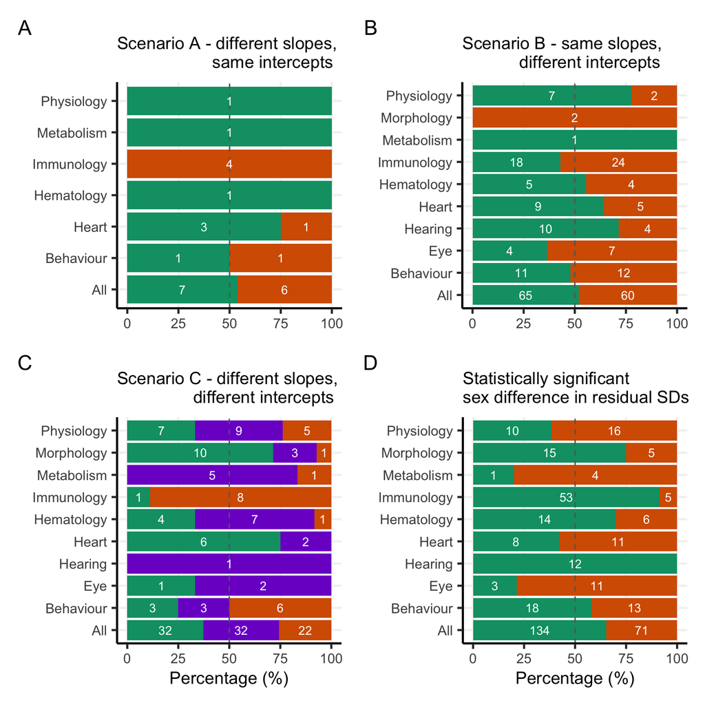

```r
# set colour for males and females

colours <- c("#D55E00", "#009E73")  # c('#882255','#E69F00')
colours2 <- c("#D55E00", "#7D26CD", "#009E73")

# sex bias in slope parameter under scenario A
dat_p1 <- dat_slopes %>%
    group_by_at(vars(Category)) %>%
    summarise(malebias = sum(m_slope > f_slope), femalebias = sum(f_slope > m_slope),
        total = malebias + femalebias, malepercent = malebias * 100/total, femalepercent = femalebias *
            100/total)


dat_p1 <- gather(as.data.frame(dat_p1), key = sex, value = percent, malepercent:femalepercent,
    factor_key = TRUE)


dat_p1$samplesize <- with(dat_p1, ifelse(sex == "malepercent", malebias, femalebias))

# Adding All
dat_p1 %>%
    group_by(sex) %>%
    summarise(malebias = sum(malebias), femalebias = sum(femalebias), total = sum(total),
        ) -> part

part %>%
    mutate(Category = "All", sex = c("malepercent", "femalepercent"), percent = c(100 *
        (malebias[1]/total[1]), 100 * (femalebias[1]/total[1])), samplesize = c(malebias[1],
        femalebias[1])) -> part


# select(Category, malebias, femalebias, total, sex, percent, samplesize)
dat_p1 <- bind_rows(dat_p1, part)



p1 <- ggplot(dat_p1) + aes(x = Category, y = percent, fill = sex) + geom_col() +
    geom_hline(yintercept = 50, linetype = "dashed", color = "gray40") + geom_text(data = subset(dat_p1,
    samplesize != 0), aes(label = samplesize), position = position_stack(vjust = 0.5),
    color = "white", size = 3.5) + scale_fill_manual(values = colours) + theme_bw(base_size = 18) +
    theme(strip.text.y = element_text(angle = 270, size = 10, margin = margin(t = 15,
        r = 15, b = 15, l = 15)), strip.text.x = element_text(size = 12), strip.background = element_rect(colour = NULL,
        linetype = "blank", fill = "gray90"), text = element_text(size = 14), panel.spacing = unit(0.5,
        "lines"), panel.border = element_blank(), axis.line = element_line(), panel.grid.major.x = element_line(linetype = "solid",
        colour = "gray95"), panel.grid.major.y = element_line(linetype = "solid",
        colour = "gray95"), panel.grid.minor.y = element_blank(), panel.grid.minor.x = element_blank(),
        axis.title.x = element_blank(), axis.title.y = element_blank(), plot.title = element_text(size = 14),
        legend.position = "none") + coord_flip() + labs(title = "Scenario A - different slopes, \n                    same intercepts")



# sex bias in intercept parameter - scenario B
dat_p2 <- dat_int %>%
    group_by_at(vars(Category)) %>%
    summarise(malebias = sum(m_intercept > f_intercept), femalebias = sum(f_intercept >
        m_intercept), total = malebias + femalebias, malepercent = malebias * 100/total,
        femalepercent = femalebias * 100/total)

dat_p2 <- gather(as.data.frame(dat_p2), key = sex, value = percent, malepercent:femalepercent,
    factor_key = TRUE)

dat_p2$samplesize <- with(dat_p2, ifelse(sex == "malepercent", malebias, femalebias))

# addeing All
dat_p2 %>%
    group_by(sex) %>%
    summarise(malebias = sum(malebias), femalebias = sum(femalebias), total = sum(total),
        ) -> part2

part2 %>%
    mutate(Category = "All", sex = c("malepercent", "femalepercent"), percent = c(100 *
        (malebias[1]/total[1]), 100 * (femalebias[1]/total[1])), samplesize = c(malebias[1],
        femalebias[1])) -> part2


# select(Category, malebias, femalebias, total, sex, percent, samplesize)
dat_p2 <- bind_rows(dat_p2, part2)


p2 <- ggplot(dat_p2) + aes(x = Category, y = percent, fill = sex) + geom_col() +
    geom_hline(yintercept = 50, linetype = "dashed", color = "gray40") + geom_text(data = subset(dat_p2,
    samplesize != 0), aes(label = samplesize), position = position_stack(vjust = 0.5),
    color = "white", size = 3.5) + scale_fill_manual(values = colours) + theme_bw(base_size = 18) +
    theme(strip.text.y = element_text(angle = 270, size = 10, margin = margin(t = 15,
        r = 15, b = 15, l = 15)), strip.text.x = element_text(size = 12), strip.background = element_rect(colour = NULL,
        linetype = "blank", fill = "gray90"), text = element_text(size = 14), panel.spacing = unit(0.5,
        "lines"), panel.border = element_blank(), axis.line = element_line(), panel.grid.major.x = element_line(linetype = "solid",
        colour = "gray95"), panel.grid.major.y = element_line(linetype = "solid",
        color = "gray95"), panel.grid.minor.y = element_blank(), panel.grid.minor.x = element_blank(),
        axis.title.x = element_blank(), axis.title.y = element_blank(), plot.title = element_text(size = 14),
        legend.position = "none") + coord_flip() + labs(title = "Scenario B - same slopes, \n            different intercepts")


# sex bias in sig intercept and slope parameter - scenario C
dat_p3 <- dat_intSlopes %>%
    group_by_at(vars(Category)) %>%
    summarise(malebias = sum(m_intercept > f_intercept & m_slope > f_slope), mixed = sum(m_intercept >
        f_intercept & m_slope < f_slope, m_intercept < f_intercept & m_slope > f_slope),
        femalebias = sum(f_intercept > m_intercept & f_slope > m_slope), total = malebias +
            mixed + femalebias, malepercent = malebias * 100/total, mixedpercent = mixed *
            100/total, femalepercent = femalebias * 100/total)

dat_p3 <- gather(as.data.frame(dat_p3), key = sex, value = percent, malepercent:femalepercent,
    factor_key = TRUE)
dat_p3$samplesize <- with(dat_p3, ifelse(sex == "malepercent", malebias, ifelse(sex ==
    "mixedpercent", mixed, femalebias)))


# addeng All
dat_p3 %>%
    group_by(sex) %>%
    summarise(malebias = sum(malebias), mixed = sum(mixed), femalebias = sum(femalebias),
        total = sum(total), ) -> part3

part3 %>%
    mutate(Category = "All", sex = c("malepercent", "mixedpercent", "femalepercent"),
        percent = c(100 * (malebias[1]/total[1]), 100 * (mixed[1]/total[1]), 100 *
            (femalebias[1]/total[1])), samplesize = c(malebias[1], mixed[1], femalebias[1])) ->
    part3


# select(Category, malebias, femalebias, total, sex, percent, samplesize)
dat_p3 <- bind_rows(dat_p3, part3)

p3 <- ggplot(dat_p3) + aes(x = Category, y = percent, fill = sex) + geom_col() +
    geom_hline(yintercept = 50, linetype = "dashed", color = "gray40") + geom_text(data = subset(dat_p3,
    samplesize != 0), aes(label = samplesize), position = position_stack(vjust = 0.5),
    color = "white", size = 3.5) + scale_fill_manual(values = colours2) + theme_bw(base_size = 18) +
    theme(strip.text.y = element_text(angle = 270, size = 10, margin = margin(t = 15,
        r = 15, b = 15, l = 15)), strip.text.x = element_text(size = 12), strip.background = element_rect(colour = NULL,
        linetype = "blank", fill = "gray90"), text = element_text(size = 14), panel.spacing = unit(0.5,
        "lines"), panel.border = element_blank(), axis.line = element_line(), panel.grid.major.x = element_line(linetype = "solid",
        colour = "gray95"), panel.grid.major.y = element_line(linetype = "solid",
        color = "gray95"), panel.grid.minor.y = element_blank(), panel.grid.minor.x = element_blank(),
        axis.title.y = element_blank(), plot.title = element_text(size = 14), legend.position = "none") +
    ylab("Percentage (%)") + coord_flip() + labs(title = "Scenario C - different slopes, \n                different intercepts")

# sex bias in sd
dat_p4 <- dat %>%
    filter(p_val_sd <= 0.05) %>%
    group_by_at(vars(Category)) %>%
    summarise(malebias = sum(m_sd > f_sd), femalebias = sum(f_sd > m_sd), total = malebias +
        femalebias, malepercent = malebias * 100/total, femalepercent = femalebias *
        100/total)


dat_p4 <- gather(as.data.frame(dat_p4), key = sex, value = percent, malepercent:femalepercent,
    factor_key = TRUE)

dat_p4$samplesize <- with(dat_p4, ifelse(sex == "malepercent", malebias, femalebias))


# addeing All
dat_p4 %>%
    group_by(sex) %>%
    summarise(malebias = sum(malebias), femalebias = sum(femalebias), total = sum(total),
        ) -> part4

part4 %>%
    mutate(Category = "All", sex = c("malepercent", "femalepercent"), percent = c(100 *
        (malebias[1]/total[1]), 100 * (femalebias[1]/total[1])), samplesize = c(malebias[1],
        femalebias[1])) -> part4


# select(Category, malebias, femalebias, total, sex, percent, samplesize)
dat_p4 <- bind_rows(dat_p4, part4)

p4 <- ggplot(dat_p4) + aes(x = Category, y = percent, fill = sex) + geom_col() +
    geom_hline(yintercept = 50, linetype = "dashed", color = "gray40") + geom_text(data = subset(dat_p4,
    samplesize != 0), aes(label = samplesize), position = position_stack(vjust = 0.5),
    color = "white", size = 3.5) + scale_fill_manual(values = colours) + theme_bw(base_size = 18) +
    theme(strip.text.y = element_text(angle = 270, size = 10, margin = margin(t = 15,
        r = 15, b = 15, l = 15)), strip.text.x = element_text(size = 12), strip.background = element_rect(colour = NULL,
        linetype = "blank", fill = "gray90"), text = element_text(size = 14), panel.spacing = unit(0.5,
        "lines"), panel.border = element_blank(), axis.line = element_line(), panel.grid.major.x = element_line(linetype = "solid",
        colour = "gray95"), panel.grid.major.y = element_line(linetype = "solid",
        color = "gray95"), panel.grid.minor.y = element_blank(), panel.grid.minor.x = element_blank(),
        axis.title.y = element_blank(), plot.title = element_text(size = 14), legend.position = "none") +
    ylab("Percentage (%)") + coord_flip() + labs(title = "Statistically significant\nsex difference in residual SDs")

# putting all together
(p1 + p2)/(p3 + p4) + plot_annotation(tag_levels = "A")
```

**Fig. 2** Sex biases for mice phenotypic traits arrange in functional groups (see the main tex)

## Functional categories in the dataset

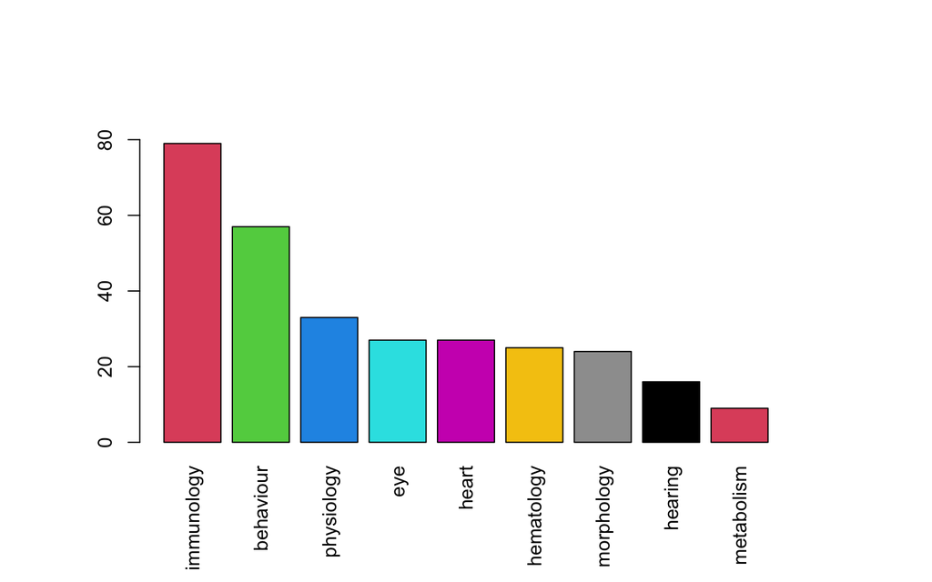

```r
par(mar = c(6, 6, 6, 6))
v = c(57, 27, 16, 27, 25, 79, 9, 24, 33)
t = c("behaviour", "eye", "hearing", "heart", "hematology", "immunology", "metabolism",
    "morphology", "physiology")
d = data.frame(trait = t, n = v)
d = d[order(d$n, decreasing = TRUE), ]
barplot(height = d$n, names.arg = d$trait, las = 3, col = seq_along(d$trait) + 1,
    ylim = c(0, 80))
```

**Fig. S1** The number of traits in each of 9 functional categories.

# Meta-analysis

## Calculating absolute effect sizes

Here we convert our effect sizes to absolute values assuming folded normal distributions.

```r
# for folded nornaml distribution see:
# https://en.wikipedia.org/wiki/Folded_normal_distribution

# folded mean
folded_mu <- function(mean, variance) {
    mu <- mean
    sigma <- sqrt(variance)
    fold_mu <- sigma * sqrt(2/pi) * exp((-mu^2)/(2 * sigma^2)) + mu * (1 - 2 * pnorm(-mu/sigma))
    fold_mu
}

# folded variance
folded_v <- function(mean, variance) {
    mu <- mean
    sigma <- sqrt(variance)
    fold_mu <- sigma * sqrt(2/pi) * exp((-mu^2)/(2 * sigma^2)) + mu * (1 - 2 * pnorm(-mu/sigma))
    fold_se <- sqrt(mu^2 + sigma^2 - fold_mu^2)
    # adding se to make bigger mean
    fold_v <- fold_se^2
    fold_v
}


dat <- dat %>%
    mutate(abs_int = folded_mu(fm_diff_int, fm_diff_int_se^2), abs_slope = folded_mu(fm_diff_slope,
        fm_diff_slope_se^2), abs_lnVR = folded_mu(lnVR, VlnVR), V_abs_int = folded_v(fm_diff_int,
        fm_diff_int_se^2), V_abs_slope = folded_v(fm_diff_slope, fm_diff_slope_se^2),
        V_abs_lnVR = folded_v(lnVR, VlnVR))
```

## Comparing sex difference in intercepts

This is a meta-analytic model of sex differences in intercepts (mean traits). We use the `rubust` function calculates to see whether our results form the model is robust (consistent).

```r
modelia <- rma.mv(yi = abs_int, V = V_abs_int, random = list(~1 | Category, ~1 |
    parameter_group, ~1 | obs), data = dat)
summary(modelia)
```

```
##
## Multivariate Meta-Analysis Model (k = 297; method: REML)
##
##   logLik  Deviance       AIC       BIC      AICc
##  39.8472  -79.6944  -71.6944  -56.9329  -71.5569
##
## Variance Components:
##
##             estim    sqrt  nlvls  fixed           factor
## sigma^2.1  0.0084  0.0919      9     no         Category
## sigma^2.2  0.0361  0.1900    181     no  parameter_group
## sigma^2.3  0.0189  0.1376    297     no              obs
##
## Test for Heterogeneity:
## Q(df = 296) = 172649.9220, p-val < .0001
##
## Model Results:
##
## estimate      se    zval    pval   ci.lb   ci.ub
##   0.2318  0.0364  6.3642  <.0001  0.1604  0.3031  ***
##
## ---
## Signif. codes:  0 '***' 0.001 '**' 0.01 '*' 0.05 '.' 0.1 ' ' 1
```

```r
# robust variance estimator
robust(modelia, cluster = dat$parameter_group)
```

```
##
## Number of outcomes:   297
## Number of clusters:   181
## Outcomes per cluster: 1-10 (mean: 1.64, median: 1)
##
## Model Results:
##
## estimate      se     tval   df    pval   ci.lb   ci.ub
##   0.2318  0.0205  11.2873  180  <.0001  0.1913  0.2723  ***
##
## ---
## Signif. codes:  0 '***' 0.001 '**' 0.01 '*' 0.05 '.' 0.1 ' ' 1
```

```r
# I2 (heterogeneity)
i2_ml(modelia)
```

```
##           I2_Total        I2_Category I2_parameter_group             I2_obs
##           99.84613           13.27909           56.79289           29.77415
```

This is a meta-regression model of sex differences in intercepts (mean traits) with a functional category as a moderator. We used the `rubust` function calculates to see whether our results form the model is robust (consistent).

```r
model1a <- rma.mv(yi = abs_int, V = V_abs_int, mod = ~Category - 1, random = list(~1 |
    parameter_group, ~1 | obs), data = dat)
summary(model1a)
```

```
##
## Multivariate Meta-Analysis Model (k = 297; method: REML)
##
##   logLik  Deviance       AIC       BIC      AICc
##  46.6795  -93.3590  -71.3590  -31.0664  -70.4024
##
## Variance Components:
##
##             estim    sqrt  nlvls  fixed           factor
## sigma^2.1  0.0358  0.1892    181     no  parameter_group
## sigma^2.2  0.0191  0.1382    297     no              obs
##
## Test for Residual Heterogeneity:
## QE(df = 288) = 151046.5157, p-val < .0001
##
## Test of Moderators (coefficients 1:9):
## QM(df = 9) = 217.6359, p-val < .0001
##
## Model Results:
##
##                     estimate      se    zval    pval    ci.lb   ci.ub
## CategoryBehaviour     0.1769  0.0370  4.7801  <.0001   0.1044  0.2495  ***
## CategoryEye           0.2925  0.0593  4.9292  <.0001   0.1762  0.4088  ***
## CategoryHearing       0.0845  0.1385  0.6104  0.5416  -0.1869  0.3559
## CategoryHeart         0.1545  0.0448  3.4472  0.0006   0.0667  0.2424  ***
## CategoryHematology    0.2268  0.0560  4.0497  <.0001   0.1170  0.3365  ***
## CategoryImmunology    0.1098  0.0457  2.4013  0.0163   0.0202  0.1995    *
## CategoryMetabolism    0.3602  0.0756  4.7625  <.0001   0.2120  0.5084  ***
## CategoryMorphology    0.2175  0.0514  4.2339  <.0001   0.1168  0.3182  ***
## CategoryPhysiology    0.4101  0.0415  9.8760  <.0001   0.3287  0.4915  ***
##
## ---
## Signif. codes:  0 '***' 0.001 '**' 0.01 '*' 0.05 '.' 0.1 ' ' 1
```

```r
robust(model1a, cluster = dat$parameter_group)
```

```
##
## Number of outcomes:   297
## Number of clusters:   181
## Outcomes per cluster: 1-10 (mean: 1.64, median: 1)
##
## Test of Moderators (coefficients 1:9):
## F(df1 = 9, df2 = 172) = 38.2546, p-val < .0001
##
## Model Results:
##
##                     estimate      se     tval   df    pval   ci.lb   ci.ub
## CategoryBehaviour     0.1769  0.0303   5.8406  172  <.0001  0.1171  0.2367  ***
## CategoryEye           0.2925  0.0631   4.6325  172  <.0001  0.1679  0.4171  ***
## CategoryHearing       0.0845  0.0080  10.5761  172  <.0001  0.0687  0.1003  ***
## CategoryHeart         0.1545  0.0273   5.6639  172  <.0001  0.1007  0.2084  ***
## CategoryHematology    0.2268  0.0431   5.2586  172  <.0001  0.1416  0.3119  ***
## CategoryImmunology    0.1098  0.0150   7.3252  172  <.0001  0.0802  0.1394  ***
## CategoryMetabolism    0.3602  0.1277   2.8210  172  0.0054  0.1082  0.6122   **
## CategoryMorphology    0.2175  0.0579   3.7577  172  0.0002  0.1033  0.3318  ***
## CategoryPhysiology    0.4101  0.0631   6.4989  172  <.0001  0.2855  0.5346  ***
##
## ---
## Signif. codes:  0 '***' 0.001 '**' 0.01 '*' 0.05 '.' 0.1 ' ' 1
```

```r
# R2 (variance explained)
r2_ml(model1a)
```

```
##    R2_marginal R2_conditional
##      0.1507731      0.7047098
```

## Comparing sex difference in slopes

This is a meta-analytic model of sex differences in slopes. We used the `rubust` function calculates to see whether our results form the model is robust (consistent).

```r
modelsa <- rma.mv(yi = abs_slope, V = V_abs_slope, random = list(~1 | Category, ~1 |
    parameter_group, ~1 | obs), data = dat)
summary(modelsa)  # not sig this means sometimes male is high other times female has steaper slops
```

```
##
## Multivariate Meta-Analysis Model (k = 297; method: REML)
##
##   logLik  Deviance       AIC       BIC      AICc
## -89.8236  179.6471  187.6471  202.4086  187.7846
##
## Variance Components:
##
##             estim    sqrt  nlvls  fixed           factor
## sigma^2.1  0.0191  0.1380      9     no         Category
## sigma^2.2  0.0748  0.2734    181     no  parameter_group
## sigma^2.3  0.0000  0.0000    297     no              obs
##
## Test for Heterogeneity:
## Q(df = 296) = 2241.2153, p-val < .0001
##
## Model Results:
##
## estimate      se    zval    pval   ci.lb   ci.ub
##   0.3935  0.0546  7.2063  <.0001  0.2865  0.5006  ***
##
## ---
## Signif. codes:  0 '***' 0.001 '**' 0.01 '*' 0.05 '.' 0.1 ' ' 1
```

```r
robust(modelsa, cluster = dat$parameter_group)
```

```
##
## Number of outcomes:   297
## Number of clusters:   181
## Outcomes per cluster: 1-10 (mean: 1.64, median: 1)
##
## Model Results:
##
## estimate      se     tval   df    pval   ci.lb   ci.ub
##   0.3935  0.0288  13.6652  180  <.0001  0.3367  0.4504  ***
##
## ---
## Signif. codes:  0 '***' 0.001 '**' 0.01 '*' 0.05 '.' 0.1 ' ' 1
```

```r
# I2 (heterogeneity)
i2_ml(modelia)
```

```
##           I2_Total        I2_Category I2_parameter_group             I2_obs
##           99.84613           13.27909           56.79289           29.77415
```

This is a meta-regression model of sex differences in slopes with a functional category as a moderator. We use the `rubust` function calculates to see whether our results form the model is robust (consistent).

```r
model2a <- rma.mv(yi = abs_slope, V = V_abs_slope, mod = ~Category - 1, random = list(~1 |
    parameter_group, ~1 | obs), data = dat)
summary(model2a)
```

```
##
## Multivariate Meta-Analysis Model (k = 297; method: REML)
##
##   logLik  Deviance       AIC       BIC      AICc
## -78.6572  157.3145  179.3145  219.6071  180.2710
##
## Variance Components:
##
##             estim    sqrt  nlvls  fixed           factor
## sigma^2.1  0.0765  0.2765    181     no  parameter_group
## sigma^2.2  0.0000  0.0000    297     no              obs
##
## Test for Residual Heterogeneity:
## QE(df = 288) = 1607.9061, p-val < .0001
##
## Test of Moderators (coefficients 1:9):
## QM(df = 9) = 267.6837, p-val < .0001
##
## Model Results:
##
##                     estimate      se    zval    pval    ci.lb   ci.ub
## CategoryBehaviour     0.3295  0.0590  5.5858  <.0001   0.2139  0.4451  ***
## CategoryEye           0.7973  0.1491  5.3456  <.0001   0.5049  1.0896  ***
## CategoryHearing       0.0952  0.1966  0.4843  0.6282  -0.2901  0.4806
## CategoryHeart         0.3111  0.0626  4.9687  <.0001   0.1884  0.4339  ***
## CategoryHematology    0.2230  0.0714  3.1241  0.0018   0.0831  0.3629   **
## CategoryImmunology    0.3100  0.0680  4.5598  <.0001   0.1767  0.4432  ***
## CategoryMetabolism    0.6099  0.1019  5.9859  <.0001   0.4102  0.8096  ***
## CategoryMorphology    0.3845  0.0649  5.9251  <.0001   0.2573  0.5117  ***
## CategoryPhysiology    0.5230  0.0568  9.2031  <.0001   0.4116  0.6343  ***
##
## ---
## Signif. codes:  0 '***' 0.001 '**' 0.01 '*' 0.05 '.' 0.1 ' ' 1
```

```r
robust(model2a, cluster = dat$parameter_group)
```

```
##
## Number of outcomes:   297
## Number of clusters:   181
## Outcomes per cluster: 1-10 (mean: 1.64, median: 1)
##
## Test of Moderators (coefficients 1:9):
## F(df1 = 9, df2 = 172) = 40.6301, p-val < .0001
##
## Model Results:
##
##                     estimate      se     tval   df    pval   ci.lb   ci.ub
## CategoryBehaviour     0.3295  0.0508   6.4807  172  <.0001  0.2291  0.4298  ***
## CategoryEye           0.7973  0.1924   4.1435  172  <.0001  0.4175  1.1771  ***
## CategoryHearing       0.0952  0.0356   2.6739  172  0.0082  0.0249  0.1655   **
## CategoryHeart         0.3111  0.0398   7.8260  172  <.0001  0.2327  0.3896  ***
## CategoryHematology    0.2230  0.0345   6.4691  172  <.0001  0.1550  0.2911  ***
## CategoryImmunology    0.3100  0.0287  10.7865  172  <.0001  0.2533  0.3667  ***
## CategoryMetabolism    0.6099  0.1341   4.5464  172  <.0001  0.3451  0.8747  ***
## CategoryMorphology    0.3845  0.0737   5.2204  172  <.0001  0.2391  0.5299  ***
## CategoryPhysiology    0.5230  0.0858   6.0969  172  <.0001  0.3537  0.6923  ***
##
## ---
## Signif. codes:  0 '***' 0.001 '**' 0.01 '*' 0.05 '.' 0.1 ' ' 1
```

```r
# R2 (variance explained)
r2_ml(model2a)
```

```
##    R2_marginal R2_conditional
##      0.2712532      1.0000000
```

## Comparing sex difference in resdiaul SDs

This is a meta-analytic model of sex differences in residual SDs. We use the `rubust` function calculates to see whether our results form the model is robust (consistent).

```r
modelsda <- rma.mv(yi = abs_lnVR, V = V_abs_lnVR, random = list(~1 | Category, ~1 |
    parameter_group, ~1 | obs), data = dat)
summary(modelsda)
```

```
##
## Multivariate Meta-Analysis Model (k = 297; method: REML)
##
##    logLik   Deviance        AIC        BIC       AICc
##  123.6613  -247.3227  -239.3227  -224.5612  -239.1852
##
## Variance Components:
##
##             estim    sqrt  nlvls  fixed           factor
## sigma^2.1  0.0039  0.0628      9     no         Category
## sigma^2.2  0.0144  0.1202    181     no  parameter_group
## sigma^2.3  0.0110  0.1049    297     no              obs
##
## Test for Heterogeneity:
## Q(df = 296) = 16662.2133, p-val < .0001
##
## Model Results:
##
## estimate      se    zval    pval   ci.lb   ci.ub
##   0.1531  0.0248  6.1673  <.0001  0.1044  0.2017  ***
##
## ---
## Signif. codes:  0 '***' 0.001 '**' 0.01 '*' 0.05 '.' 0.1 ' ' 1
```

```r
robust(modelsda, cluster = dat$parameter_group)
```

```
##
## Number of outcomes:   297
## Number of clusters:   181
## Outcomes per cluster: 1-10 (mean: 1.64, median: 1)
##
## Model Results:
##
## estimate      se     tval   df    pval   ci.lb   ci.ub
##   0.1531  0.0143  10.6717  180  <.0001  0.1248  0.1813  ***
##
## ---
## Signif. codes:  0 '***' 0.001 '**' 0.01 '*' 0.05 '.' 0.1 ' ' 1
```

```r
# I2 (heterogeneity)
i2_ml(modelsda)
```

```
##           I2_Total        I2_Category I2_parameter_group             I2_obs
##           99.19439           13.32916           48.73086           37.13437
```

This is a meta-regression model of sex differences in residual SDs with a functional category as a moderator. We use the `rubust` function calculates to see whether our results form the model is robust (consistent).

```r
# meta-regression
model3a <- rma.mv(yi = abs_lnVR, V = V_abs_lnVR, mod = ~Category - 1, random = list(~1 |
    parameter_group, ~1 | obs), data = dat)
summary(model3a)
```

```
##
## Multivariate Meta-Analysis Model (k = 297; method: REML)
##
##    logLik   Deviance        AIC        BIC       AICc
##  127.5536  -255.1072  -233.1072  -192.8146  -232.1507
##
## Variance Components:
##
##             estim    sqrt  nlvls  fixed           factor
## sigma^2.1  0.0150  0.1223    181     no  parameter_group
## sigma^2.2  0.0108  0.1041    297     no              obs
##
## Test for Residual Heterogeneity:
## QE(df = 288) = 14212.6156, p-val < .0001
##
## Test of Moderators (coefficients 1:9):
## QM(df = 9) = 193.7996, p-val < .0001
##
## Model Results:
##
##                     estimate      se    zval    pval    ci.lb   ci.ub
## CategoryBehaviour     0.1135  0.0252  4.4945  <.0001   0.0640  0.1629  ***
## CategoryEye           0.3098  0.0412  7.5181  <.0001   0.2290  0.3906  ***
## CategoryHearing       0.1037  0.0906  1.1441  0.2526  -0.0739  0.2812
## CategoryHeart         0.0937  0.0309  3.0333  0.0024   0.0331  0.1542   **
## CategoryHematology    0.1821  0.0380  4.7952  <.0001   0.1077  0.2565  ***
## CategoryImmunology    0.2216  0.0313  7.0853  <.0001   0.1603  0.2829  ***
## CategoryMetabolism    0.0739  0.0526  1.4059  0.1598  -0.0291  0.1769
## CategoryMorphology    0.1398  0.0351  3.9846  <.0001   0.0710  0.2085  ***
## CategoryPhysiology    0.1140  0.0285  3.9919  <.0001   0.0580  0.1699  ***
##
## ---
## Signif. codes:  0 '***' 0.001 '**' 0.01 '*' 0.05 '.' 0.1 ' ' 1
```

```r
# R2 (variance explained)
r2_ml(model3a)
```

```
##    R2_marginal R2_conditional
##      0.1504465      0.6431092
```

## Obtaining correlations among intercepts, slopes and SDs

```r
# tri-variate model

mod_lnsd <- bf(log(abs_lnVR) | se(sqrt(V_abs_lnVR)/abs_lnVR) ~ -1 + Category + (1 |
    q | parameter_group))
mod_lnslp <- bf(log(abs_slope) | se(sqrt(V_abs_slope)/abs_slope) ~ -1 + Category +
    (1 | q | parameter_group))
mod_lnint <- bf(log(abs_int) | se(sqrt(V_abs_int)/abs_int) ~ -1 + Category + (1 |
    q | parameter_group))

fit_3b <- brm(mod_lnsd + mod_lnslp + mod_lnint, data = dat, chains = 2, cores = 2,
    iter = 4000, warmup = 1000, backend = "cmdstanr")

summary(fit_3b)

# saving the model saveRDS(fit_3b, file = here('data', 'fit_3b.rds'))
```

```
##  Family: MV(gaussian, gaussian, gaussian)
##   Links: mu = identity; sigma = identity
##          mu = identity; sigma = identity
##          mu = identity; sigma = identity
## Formula: log(abs_lnVR) | se(sqrt(V_abs_lnVR)/abs_lnVR) ~ -1 + Category + (1 | q | parameter_group)
##          log(abs_slope) | se(sqrt(V_abs_slope)/abs_slope) ~ -1 + Category + (1 | q | parameter_group)
##          log(abs_int) | se(sqrt(V_abs_int)/abs_int) ~ -1 + Category + (1 | q | parameter_group)
##    Data: dat (Number of observations: 297)
##   Draws: 2 chains, each with iter = 3000; warmup = 0; thin = 1;
##          total post-warmup draws = 6000
##
## Group-Level Effects:
## ~parameter_group (Number of levels: 181)
##                                                 Estimate Est.Error l-95% CI
## sd(logabslnVR_Intercept)                            0.91      0.06     0.81
## sd(logabsslope_Intercept)                           0.83      0.06     0.72
## sd(logabsint_Intercept)                             1.08      0.07     0.96
## cor(logabslnVR_Intercept,logabsslope_Intercept)     0.19      0.09     0.01
## cor(logabslnVR_Intercept,logabsint_Intercept)       0.07      0.09    -0.10
## cor(logabsslope_Intercept,logabsint_Intercept)      0.56      0.07     0.42
##                                                 u-95% CI Rhat Bulk_ESS Tail_ESS
## sd(logabslnVR_Intercept)                            1.03 1.00     1038     1983
## sd(logabsslope_Intercept)                           0.96 1.00     1868     3397
## sd(logabsint_Intercept)                             1.21 1.00     1345     2566
## cor(logabslnVR_Intercept,logabsslope_Intercept)     0.36 1.00      904     1945
## cor(logabslnVR_Intercept,logabsint_Intercept)       0.24 1.00      799     1810
## cor(logabsslope_Intercept,logabsint_Intercept)      0.68 1.01      947     1826
##
## Population-Level Effects:
##                                Estimate Est.Error l-95% CI u-95% CI Rhat
## logabslnVR_CategoryBehaviour      -2.45      0.17    -2.77    -2.13 1.00
## logabslnVR_CategoryEye            -1.27      0.26    -1.79    -0.76 1.00
## logabslnVR_CategoryHearing        -1.93      0.64    -3.19    -0.66 1.00
## logabslnVR_CategoryHeart          -2.44      0.18    -2.80    -2.09 1.00
## logabslnVR_CategoryHematology     -1.89      0.24    -2.36    -1.41 1.00
## logabslnVR_CategoryImmunology     -1.42      0.21    -1.82    -1.01 1.00
## logabslnVR_CategoryMetabolism     -3.74      0.27    -4.27    -3.22 1.00
## logabslnVR_CategoryMorphology     -2.39      0.22    -2.83    -1.98 1.00
## logabslnVR_CategoryPhysiology     -2.49      0.17    -2.81    -2.15 1.00
## logabsslope_CategoryBehaviour     -0.85      0.16    -1.16    -0.54 1.00
```

[output cut: 50 more lines]

```
## sigma_logabsint       0.00      0.00     0.00     0.00   NA       NA       NA
##
## Residual Correlations:
##                                Estimate Est.Error l-95% CI u-95% CI Rhat
## rescor(logabslnVR,logabsslope)     0.12      0.04     0.05     0.19 1.00
## rescor(logabslnVR,logabsint)       0.02      0.02    -0.02     0.04 1.00
## rescor(logabsslope,logabsint)      0.03      0.02    -0.00     0.06 1.00
##                                Bulk_ESS Tail_ESS
## rescor(logabslnVR,logabsslope)    10082     4896
## rescor(logabslnVR,logabsint)      10057     4555
## rescor(logabsslope,logabsint)     10666     4654
##
## Draws were sampled using sample(hmc). For each parameter, Bulk_ESS
## and Tail_ESS are effective sample size measures, and Rhat is the potential
## scale reduction factor on split chains (at convergence, Rhat = 1).
```

## Creating Figure 3

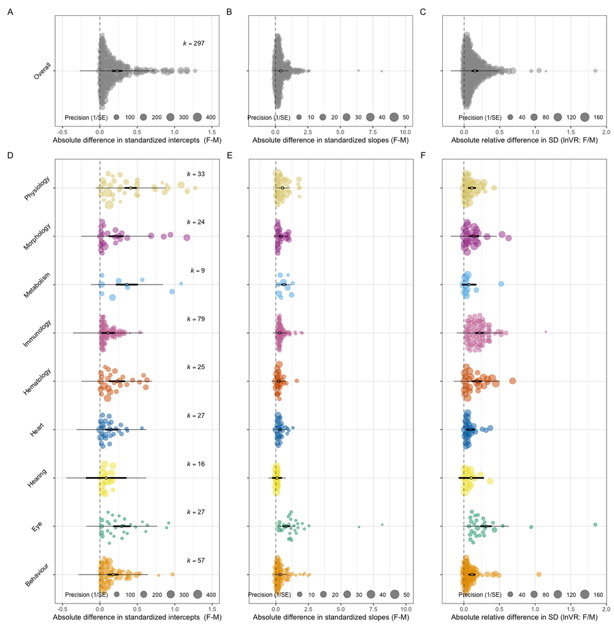

```r
# colour-blind freindly colour
cbpl <- c("#E69F00", "#009E73", "#F0E442", "#0072B2", "#D55E00", "#CC79A7", "#56B4E9",
    "#AA4499", "#DDCC77")

point.size <- 1.5

# intercept meta-analysis
p1 <- orchard_plot2(modelia, mod = "Int", xlab = "Absolute difference in standardized intercepts  (F-M)",
    angle = 45, point.size = point.size) + scale_y_discrete(labels = "Overall") +
    scale_fill_manual(values = "#999999") + scale_colour_manual(values = "#999999") +
    xlim(c(-0.5, 1.5))

# intercept meta-regression
p2 <- orchard_plot2(model1a, mod = "Category", xlab = "Absolute difference in standardized intercepts  (F-M)",
    angle = 45, point.size = point.size) + scale_fill_manual(values = cbpl) + scale_colour_manual(values = cbpl) +
    xlim(c(-0.5, 1.5))

# slope meta-analysis
p3 <- orchard_plot2(modelsa, mod = "Int", xlab = "Absolute difference in standardized slopes (F-M)",
    angle = 45, point.size = point.size) + scale_y_discrete(labels = "") + scale_fill_manual(values = "#999999") +
    scale_colour_manual(values = "#999999") + xlim(c(-1.5, 10))

# slope meta-regression
p4 <- orchard_plot2(model2a, mod = "Category", xlab = "Absolute difference in standardized slopes (F-M)",
    angle = 45, cb = F, point.size = point.size) + scale_y_discrete(labels = rep("",
    9)) + scale_fill_manual(values = cbpl) + scale_colour_manual(values = cbpl) +
    xlim(c(-1.5, 10))

# SD meta-analysis
p5 <- orchard_plot2(modelsda, mod = "Category", xlab = "Absolute relative difference in SD (lnVR: F/M)",
    angle = 45, point.size = point.size) + scale_y_discrete(labels = "") + scale_fill_manual(values = "#999999") +
    scale_colour_manual(values = "#999999") + xlim(c(-0.2, 1.9))

# SD meta-regression
p6 <- orchard_plot2(model3a, mod = "Category", xlab = "Absolute relative difference in SD (lnVR: F/M)",
    angle = 45, cb = F, point.size = point.size) + scale_y_discrete(labels = rep("",
    9)) + scale_fill_manual(values = cbpl) + scale_colour_manual(values = cbpl) +
    xlim(c(-0.2, 1.9))

# putting it together
(p1 + p3 + p5)/(p2 + p4 + p6) + plot_layout(heights = c(1, 4)) + plot_annotation(tag_levels = "A")
```

**Fig. 3** Orchard plots illustrating results of multilevel meta-analyses (see the main text)

## Creating Figure 4

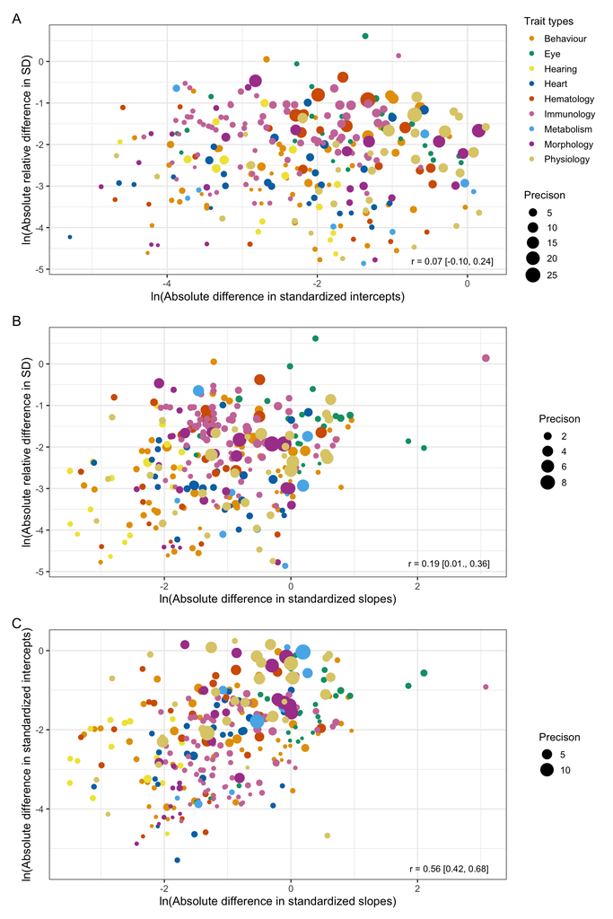

```r
# creating added precision

dat %>%
    mutate(pre_slp_int = 1/sqrt(V_abs_int/abs_int^2 + V_abs_slope/abs_slope^2), pre_slp_sd = 1/sqrt(V_abs_slope/abs_slope^2 +
        V_abs_lnVR/abs_lnVR^2), pre_int_sd = 1/sqrt(V_abs_int/abs_int^2 + V_abs_lnVR/abs_lnVR^2)) ->
    dat

# colour-blind freindly colour
cbpl <- c("#E69F00", "#009E73", "#F0E442", "#0072B2", "#D55E00", "#CC79A7", "#56B4E9",
    "#AA4499", "#DDCC77")

f1 <- ggplot(data = dat) + geom_point(aes(x = log(abs_slope), y = log(abs_int), col = Category,
    size = pre_slp_int)) + scale_fill_manual(values = cbpl) + scale_colour_manual(values = cbpl) +
    labs(x = "ln(Absolute difference in standardized slopes)", y = "ln(Absolute difference in standardized intercepts)") +
    labs(color = "Trait types", size = "Precison") + annotate(geom = "text", x = 2.5,
    y = -5.5, label = "r = 0.56 [0.42, 0.68]", size = 3) + theme_bw() + theme(legend.key.size = unit(0.5,
    "cm"), legend.title = element_text(size = 10)) + guides(col = "none")

f2 <- ggplot(data = dat) + geom_point(aes(x = log(abs_slope), y = log(abs_lnVR),
    col = Category, size = pre_slp_sd)) + scale_fill_manual(values = cbpl) + scale_colour_manual(values = cbpl) +
    labs(x = "ln(Absolute difference in standardized slopes)", y = "ln(Absolute relative difference in SD)") +
    labs(color = "Trait types", size = "Precison") + annotate(geom = "text", x = 2.5,
    y = -4.8, label = "r = 0.19 [0.01., 0.36]", size = 3) + theme_bw() + theme(legend.key.size = unit(0.5,
    "cm"), legend.title = element_text(size = 10)) + guides(col = "none")

f3 <- ggplot(data = dat) + geom_point(aes(x = log(abs_int), y = log(abs_lnVR), col = Category,
    size = pre_int_sd)) + scale_fill_manual(values = cbpl) + scale_colour_manual(values = cbpl) +
    labs(x = "ln(Absolute difference in standardized intercepts)", y = "ln(Absolute relative difference in SD)") +
    labs(color = "Trait types", size = "Precison") + annotate(geom = "text", x = -0.2,
    y = -4.8, label = "r = 0.07 [-0.10, 0.24]", size = 3) + theme_bw() + theme(legend.key.size = unit(0.5,
    "cm"), legend.title = element_text(size = 10))


f3/f2/f1 + plot_annotation(tag_levels = "A")
```

**Fig. 4** Bivariate ordinations of log absolute difference between males and females (see the main text)

# Software and package versions

```r
sessionInfo() %>%
    pander()
```

**R version 4.1.3 (2022-03-10)**

**Platform:** x86_64-apple-darwin17.0 (64-bit)

**locale:** en_AU.UTF-8||en_AU.UTF-8||en_AU.UTF-8||C||en_AU.UTF-8||en_AU.UTF-8

**attached base packages:** *stats*, *graphics*, *grDevices*, *utils*, *datasets*, *methods* and *base*

**other attached packages:** *rstan(v.2.21.3)*, *StanHeaders(v.2.21.0-7)*, *knitr(v.1.37)*, *formatR(v.1.11)*, *kableExtra(v.1.3.4)*, *brms(v.2.16.3)*, *Rcpp(v.1.0.8.3)*, *pander(v.0.6.5)*, *nlme(v.3.1-155)*, *here(v.1.0.1)*, *broom.mixed(v.0.2.7)*, *orchaRd(v.2.0)*, *patchwork(v.1.1.1)*, *poolr(v.1.1-1)*, *metafor(v.3.0-2)*, *Matrix(v.1.4-0)*, *forcats(v.0.5.1)*, *stringr(v.1.4.0)*, *dplyr(v.1.0.8)*, *purrr(v.0.3.4)*, *readr(v.2.1.2)*, *tidyr(v.1.2.0)*, *tibble(v.3.1.6)*, *ggplot2(v.3.3.5)* and *tidyverse(v.1.3.1)*

**loaded via a namespace (and not attached):** *readxl(v.1.3.1)*, *backports(v.1.4.1)*, *systemfonts(v.1.0.4)*, *plyr(v.1.8.6)*, *igraph(v.1.2.11)*, *splines(v.4.1.3)*, *crosstalk(v.1.2.0)*, *TH.data(v.1.1-0)*, *rstantools(v.2.1.1)*, *inline(v.0.3.19)*, *digest(v.0.6.29)*, *htmltools(v.0.5.2)*, *fansi(v.1.0.2)*, *magrittr(v.2.0.2)*, *checkmate(v.2.0.0)*, *tzdb(v.0.2.0)*, *modelr(v.0.1.8)*, *RcppParallel(v.5.1.5)*, *matrixStats(v.0.61.0)*, *vroom(v.1.5.7)*, *svglite(v.2.1.0)*, *sandwich(v.3.0-1)*, *xts(v.0.12.1)*, *rmdformats(v.1.0.3)*, *prettyunits(v.1.1.1)*, *colorspace(v.2.0-3)*, *rvest(v.1.0.2)*, *haven(v.2.4.3)*, *xfun(v.0.30)*, *callr(v.3.7.0)*, *crayon(v.1.5.0)*, *jsonlite(v.1.8.0)*, *survival(v.3.2-13)*, *zoo(v.1.8-9)*, *glue(v.1.6.2)*, *gtable(v.0.3.0)*, *emmeans(v.1.7.2)*, *webshot(v.0.5.2)*, *distributional(v.0.3.0)*, *pkgbuild(v.1.3.1)*, *abind(v.1.4-5)*, *scales(v.1.1.1)*, *mvtnorm(v.1.1-3)*, *DBI(v.1.1.2)*, *miniUI(v.0.1.1.1)*, *viridisLite(v.0.4.0)*, *xtable(v.1.8-4)*, *bit(v.4.0.4)*, *stats4(v.4.1.3)*, *DT(v.0.21)*, *htmlwidgets(v.1.5.4)*, *httr(v.1.4.2)*, *threejs(v.0.3.3)*, *posterior(v.1.2.1)*, *ellipsis(v.0.3.2)*, *pkgconfig(v.2.0.3)*, *loo(v.2.5.0)*, *farver(v.2.1.0)*, *sass(v.0.4.1)*, *dbplyr(v.2.1.1)*, *utf8(v.1.2.2)*, *labeling(v.0.4.2)*, *tidyselect(v.1.1.2)*, *rlang(v.1.0.2)*, *reshape2(v.1.4.4)*, *later(v.1.3.0)*, *munsell(v.0.5.0)*, *cellranger(v.1.1.0)*, *tools(v.4.1.3)*, *cli(v.3.2.0)*, *generics(v.0.1.2)*, *pacman(v.0.5.1)*, *broom(v.0.7.12)*, *mathjaxr(v.1.6-0)*, *ggridges(v.0.5.3)*, *evaluate(v.0.15)*, *fastmap(v.1.1.0)*, *yaml(v.2.3.5)*, *bit64(v.4.0.5)*, *processx(v.3.5.2)*, *fs(v.1.5.2)*, *mime(v.0.12)*, *xml2(v.1.3.3)*, *compiler(v.4.1.3)*, *bayesplot(v.1.9.0)*, *shinythemes(v.1.2.0)*, *rstudioapi(v.0.13)*, *png(v.0.1-7)*, *reprex(v.2.0.1)*, *bslib(v.0.3.1)*, *stringi(v.1.7.6)*, *highr(v.0.9)*, *ps(v.1.6.0)*, *Brobdingnag(v.1.2-7)*, *lattice(v.0.20-45)*, *markdown(v.1.1)*, *shinyjs(v.2.1.0)*, *tensorA(v.0.36.2)*, *vctrs(v.0.3.8)*, *pillar(v.1.7.0)*, *lifecycle(v.1.0.1)*, *jquerylib(v.0.1.4)*, *bridgesampling(v.1.1-2)*, *estimability(v.1.3)*, *httpuv(v.1.6.5)*, *R6(v.2.5.1)*, *bookdown(v.0.25)*, *promises(v.1.2.0.1)*, *gridExtra(v.2.3)*, *codetools(v.0.2-18)*, *MASS(v.7.3-55)*, *colourpicker(v.1.1.1)*, *gtools(v.3.9.2)*, *assertthat(v.0.2.1)*, *rprojroot(v.2.0.2)*, *withr(v.2.5.0)*, *shinystan(v.2.6.0)*, *multcomp(v.1.4-18)*, *parallel(v.4.1.3)*, *hms(v.1.1.1)*, *grid(v.4.1.3)*, *coda(v.0.19-4)*, *rmarkdown(v.2.13)*, *shiny(v.1.7.1)*, *lubridate(v.1.8.0)*, *base64enc(v.0.1-3)* and *dygraphs(v.1.1.1.6)*